# Презентация по лабораторной работе №4

Линейная алгебра

Люпп Софья Романовна

1132236039@rudn.ru

Российский университет дружбы народов

2026-10-22

# Информация

## Докладчик

- Люпп Софья Романовна
- студентка группы НКНбд-01-23
- кафедра теории вероятностей и кибербезопасности
- Российский университет дружбы народов им. П. Лумумбы
- [1132236039@rudn.ru]
- https://github.com/srluipp

# Вводная часть

## Актуальность

Julia актуальна как инструмент для научных вычислений, финансового моделирования, искусственного интеллекта, вычислений в области инженерии и физики, благодаря своей высокой производительности, простоте синтаксиса и гибкости в работе с массивами и параллельным программированием

## Объект и предмет исследования

Язык программирования Julia и среда JupyterLab

## Цели и задачи

Основной целью работы является изучение возможностей специализированных пакетов Julia для выполнения и оценки эффективности операций над объектами линейной алгебры.

# Выполнение лабораторной работы

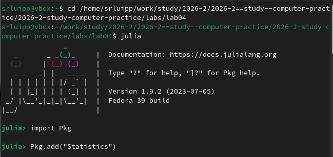

Рисунок 1: Statistics

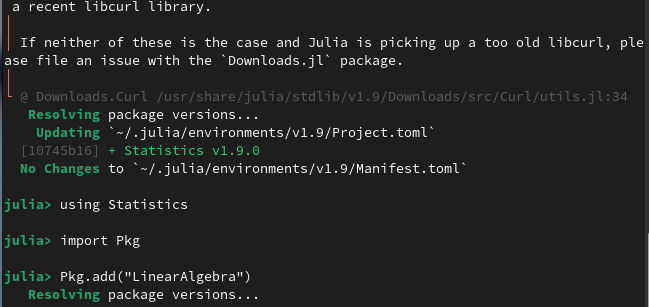

## Задания лабораторной работы

Для матрицы 4 × 3 рассмотрим поэлементные операции сложения, произведения её элементов по строкам и столбцам, а так же нахожу средние значения (рис. 3)

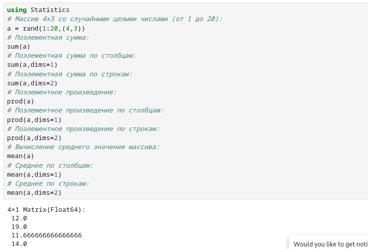

Рисунок 3: №1

## Задания лабораторной работы

Для выполнения таких операций над матрицами, как транспонирование, диагонализация, определение следа, ранга, определителя матрицы и т.п. можно воспользоваться библиотекой (пакетом) LinearAlgebra (рис. 4)

[figure not shown]

Рисунок 4: №2

## Задания лабораторной работы

Вычисляю нормы векторов и матриц, повороты, вращения(рис. 5).

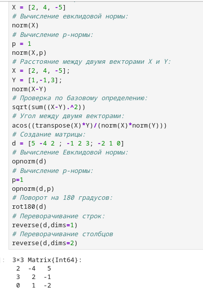

Рисунок 5: №3

## Задания лабораторной работы

Выполняю задания на матричное умножение, единичная матрица, скалярное произведение (рис. 6)

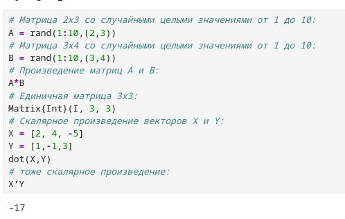

Рисунок 6: №4

## Задания лабораторной работы

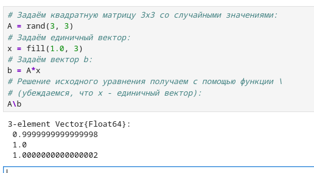

Рисунок 7: №5

## Задания лабораторной работы

Julia позволяет вычислять LU-факторизацию и определяет составной тип факторизации для его хранения: (рис. 8).

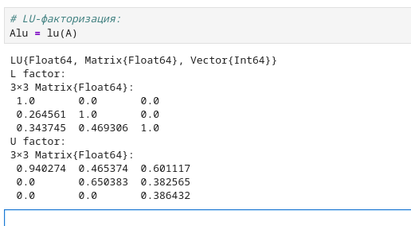

Рисунок 8: №6

## Задания лабораторной работы

Создаем матрицу и вектор перестановок и решаем СЛАУ через матрицу и через факторизацию, вычисляем детерминант (рис. 9).

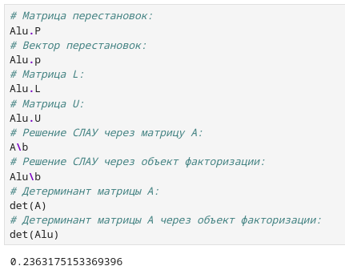

Рисунок 9: №7

## Задания лабораторной работы

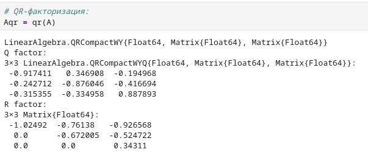

Рисунок 10: №8

## R-факторизация

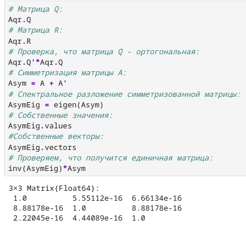

Рисунок 11: №8

## Задания лабораторной работы

Проверяем, является ли матрица симметричной (рис. 12).

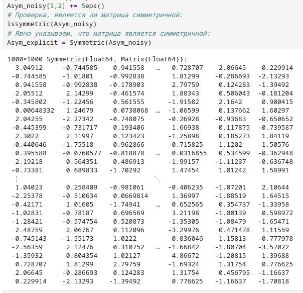

Рисунок 12: №8

## Задания лабораторной работы

Добавляем пакет Julia Benchmarks (рис. 13).

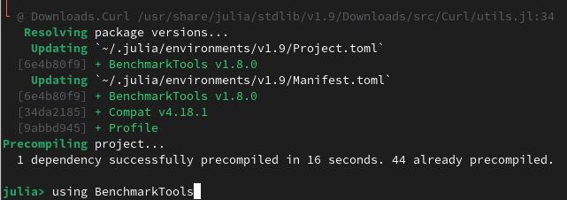

Рисунок 13: №7

## Задания лабораторной работы

Оцениваю эффективность выполнения операции по нахождению собственных значений (рис. 14)

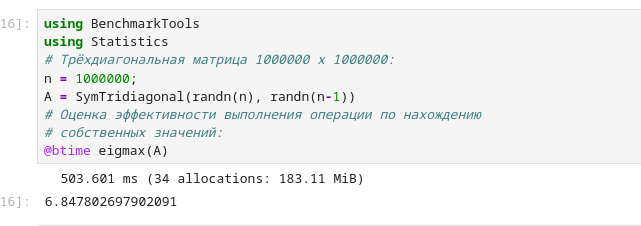

Рисунок 14: Эффективность

## Задания лабораторной работы

Решаю систему линейных уравнений с рациональными элементами без преобразования в типы элементов с плавающей запятой (для избежания проблемы с переполнением используем BigInt) (рис. 15)

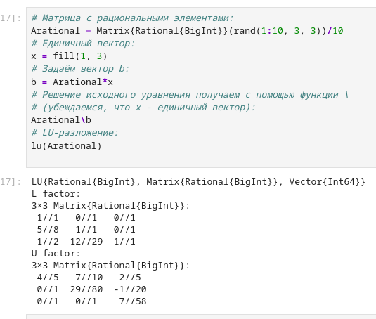

Рисунок 15: решение слау

## Задания самостоятельной работы (№1)

Вывожу вектор v, после чего для него выполняю умножение на него самого себя векторно и матрично (рис. 16)

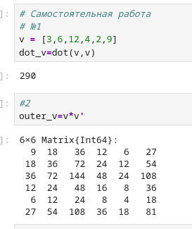

Рисунок 16: Умножение вектора на самого себя

## №2

Выполняю код для решения СЛАУ (рис. 17)

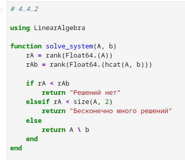

Рисунок 17: слау

## №2

Решение систем линейных уравнений (рис. 18)(рис. 19)

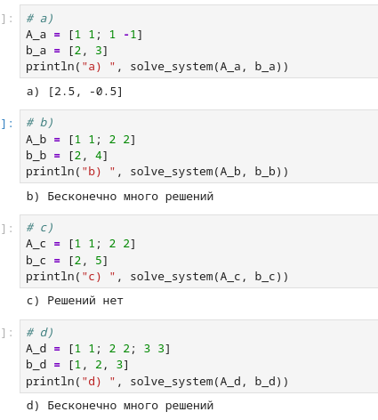

Рисунок 18: №2

## Решение систем линейных уравнений

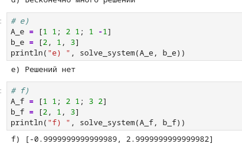

Рисунок 19: №2

## №2

Решаю систему линейных уравнений с тремя неизвестными (рис. 20)

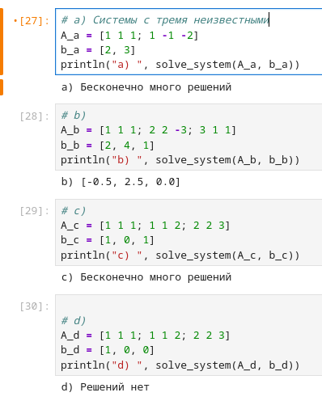

Рисунок 20: 3 неизвестные

## №3

По заданию привожу матрицы к диагональному виду (рис. 21)

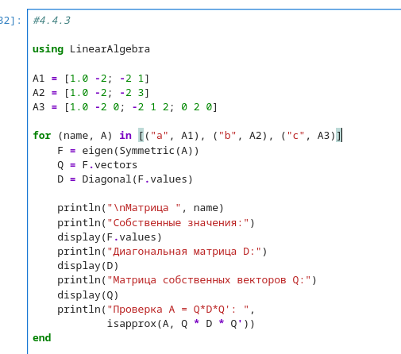

Рисунок 21: Диагональные матрицы

## №3

Вывод собственных значений матриц и их диагональный вид (рис. 22) (рис. 23).

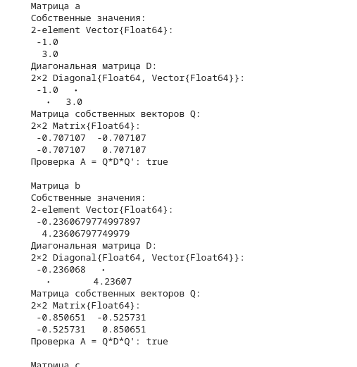

Рисунок 22: Диагональные матрицы

## диагональный вид

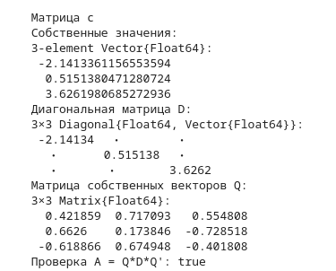

Рисунок 23: Диагональные матрицы

## №3

Выполняю вычисление над матрицами по заданию (рис. 24) (рис. 25)

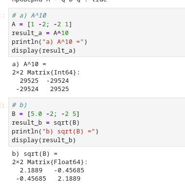

Рисунок 24: №3

## вычисление над матрицами по заданию

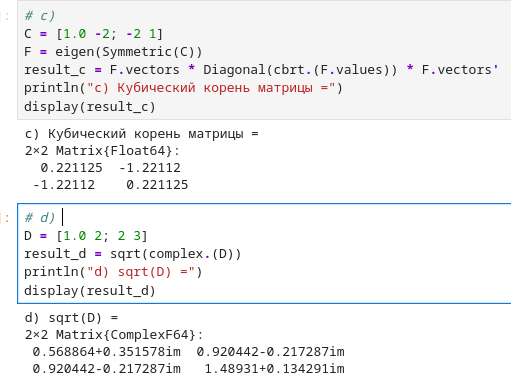

Рисунок 25: №3

## №3

Найдожу собственные значения матрицы 𝐴, привожу ее к диагональному виду, создаю нижнедиагональную матрицу (рис. 26) .

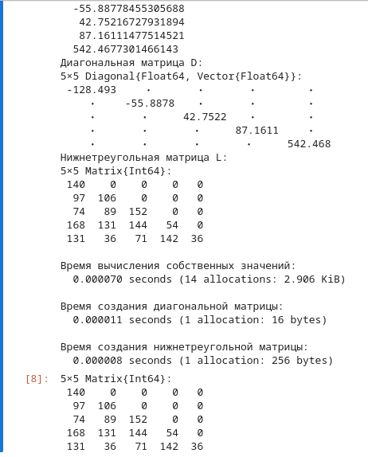

Рисунок 26: №3

## №4

Матрица 𝐴 называется продуктивной, если решение 𝑥 системы при любой неотрицательной правой части 𝑦 имеет только неотрицательные элементы 𝑥𝑖. Используя это определение, проверяю, являются ли матрицы продуктивными (рис. 27) .

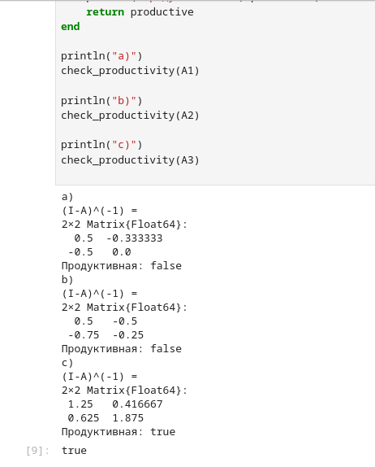

Рисунок 27: №4

## №4

Используя другой критерий продуктивности (𝐸 − 𝐴)−1, проверяю, являются ли матрицы продуктивными (рис. 28).

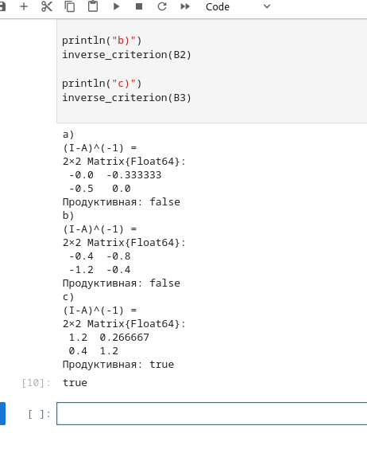

Рисунок 28: №4

## №4

Спектральный критерий продуктивности: матрица 𝐴 является продуктивной тогда и только тогда, когда все её собственные значения по модулю меньше 1. Используя этот критерий, проверяю, являются ли матрицы продуктивными(рис. 29).

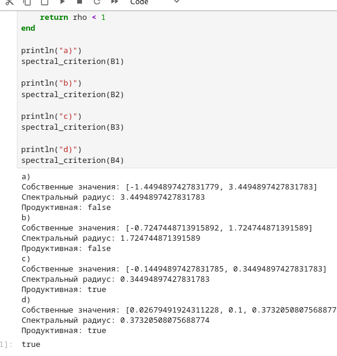

Рисунок 29: №4

# Выводы

В ходе лабораторной работы я изучила возможности специализированных пакетов Julia для выполнения и оценки эффективности операций над объектами линейной алгебры.